# Final Project - Machine Learning

Duncan McPherson

January 24, 2017

To begin, I loaded up the training data into R and split it into two pieces: a 50% training set, and a 50% test set for cross validation before applying it to the ultimate test set. I removed variables that were columns of NA or blank.

```r
read.csv("https://d396qusza40orc.cloudfront.net/predmachlearn/pml-training.csv") -> alldata
InTrain=createDataPartition(alldata$X, p=0.5, list = FALSE)
testing=alldata[-InTrain,]
training=alldata[InTrain,]
newdata = read.csv("https://d396qusza40orc.cloudfront.net/predmachlearn/pml-testing.csv")

training[,!is.na(training[1,])] -> training.nona
training.nona[,(training.nona[1,]) != ""] -> training.nona
training.nona=training.nona[,-1]
testing[,!is.na(testing[1,])] -> testing.nona
testing.nona[,(testing.nona[1,]) != ""] -> testing.nona
testing.nona=testing.nona[,-1]
```

First I did Linear Discriminate Analysis. This did not turn out so great, with an accuracy of less than 90% when applied to the cross-validation set.

```r
train(classe~., method="lda", data=training.nona) -> LDAModel
predict(LDAModel, testing.nona) -> LDAPreds
confusionMatrix(LDAPreds, testing.nona$classe)
```

```
## Confusion Matrix and Statistics
##
##           Reference
## Prediction    A    B    C    D    E
##          A 2527  200    5    0    0
##          B  245 1408  167    2    0
##          C   31  266 1489  159   15
##          D    0    9   52 1318  182
##          E    0    0    3   92 1640
##
## Overall Statistics
##
##                Accuracy : 0.8544
##                  95% CI : (0.8473, 0.8614)
##     No Information Rate : 0.2857
##     P-Value [Acc > NIR] : < 2.2e-16
##
##                   Kappa : 0.816
##  Mcnemar's Test P-Value : NA
##
## Statistics by Class:
##
##                      Class: A Class: B Class: C Class: D Class: E
## Sensitivity            0.9015   0.7477   0.8677   0.8390   0.8928
## Specificity            0.9707   0.9478   0.9418   0.9705   0.9881
## Pos Pred Value         0.9250   0.7728   0.7597   0.8443   0.9452
## Neg Pred Value         0.9610   0.9405   0.9711   0.9693   0.9756
## Prevalence             0.2857   0.1919   0.1749   0.1601   0.1873
## Detection Rate         0.2576   0.1435   0.1518   0.1344   0.1672
## Detection Prevalence   0.2785   0.1857   0.1998   0.1591   0.1769
## Balanced Accuracy      0.9361   0.8478   0.9048   0.9047   0.9404
```

Therefore, I resolved to make a Random Forest. A random forest is a mathematical agglomeration of many decision trees. I have made one below so you can see an example of the trees that make up the forest.

```r
train(classe~., method="rpart", data=training.nona) -> OneTreeModel
```

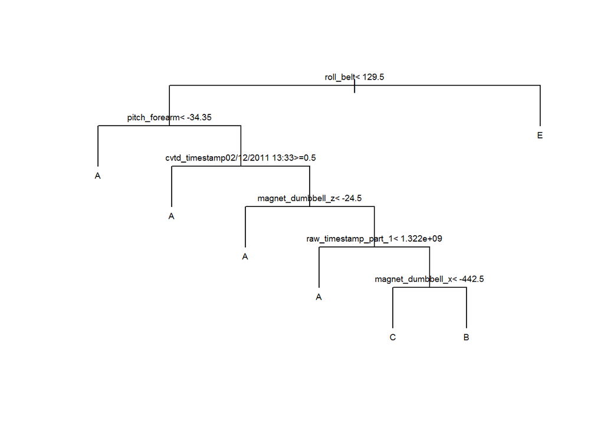

```r
plot(OneTreeModel$finalModel, uniform = TRUE, margin = 0.02)
text(OneTreeModel$finalModel, cex = 0.6)
```

Then I made the Random Forest. My computer was not happy iterating over so much data hundreds of times, but the end result was a Random Forest with over 99% accuracy! This would make my out of sample error rate less than 1%.

```r
train(classe~., method="rf", data=training.nona) -> RFModel
predict(RFModel, testing.nona) -> CrossValPred
confusionMatrix(CrossValPred, testing.nona$classe)
```

```
## Confusion Matrix and Statistics
##
##           Reference
## Prediction    A    B    C    D    E
##          A 2803    1    0    0    0
##          B    0 1882    2    0    0
##          C    0    0 1714    3    0
##          D    0    0    0 1564    3
##          E    0    0    0    4 1834
##
## Overall Statistics
##
##                Accuracy : 0.9987
##                  95% CI : (0.9977, 0.9993)
##     No Information Rate : 0.2857
##     P-Value [Acc > NIR] : < 2.2e-16
##
##                   Kappa : 0.9983
##  Mcnemar's Test P-Value : NA
##
## Statistics by Class:
##
##                      Class: A Class: B Class: C Class: D Class: E
## Sensitivity            1.0000   0.9995   0.9988   0.9955   0.9984
## Specificity            0.9999   0.9997   0.9996   0.9996   0.9995
## Pos Pred Value         0.9996   0.9989   0.9983   0.9981   0.9978
## Neg Pred Value         1.0000   0.9999   0.9998   0.9992   0.9996
## Prevalence             0.2857   0.1919   0.1749   0.1601   0.1873
## Detection Rate         0.2857   0.1918   0.1747   0.1594   0.1870
## Detection Prevalence   0.2858   0.1920   0.1750   0.1597   0.1874
## Balanced Accuracy      0.9999   0.9996   0.9992   0.9976   0.9989
```

I predicted the ultimate test data, which I here called newdata, with this model. I plugged these into the Course Prediction Quiz and got 100% accuracy.

```r
predict(RFModel, newdata)
```

```
##  [1] B A B A A E D B A A B C B A E E A B B B
## Levels: A B C D E
```

I also identified the important elements for this highly accurate model using VarImp and made a barplot of the top features:

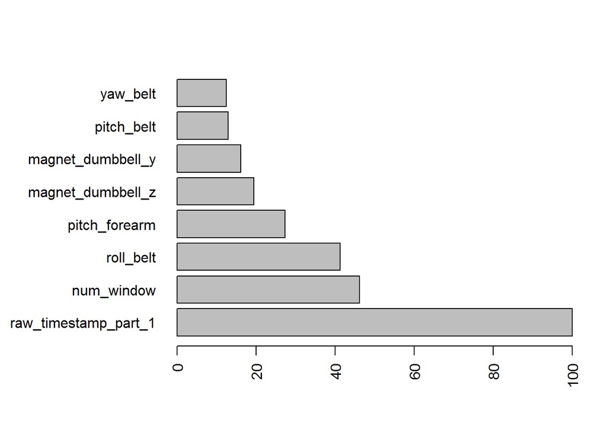

```r
varImp(RFModel) -> Important.Things
Important.Things = data.frame(Features = rownames(Important.Things[[1]]), Score = Important.Things[[1]]$Overall)
Important.Things[Important.Things$Score>quantile(Important.Things$Score,0.9),] -> Important.Things
Important.Things[order(Important.Things$Score, decreasing = TRUE),] -> Important.Things

par(mar = c(5,10,4,2))
barplot(Important.Things$Score, names.arg = Important.Things$Features, horiz= TRUE, las = 2)
```